# Lab Session: LDF Log Analysis with Spark and Dataframes

## Introduction

One of the more promising research directions at which the Semantic Web group (headed by Erik Mannens) is excelling is the research to **linked data fragments**. Semantic Data is traditionally published on the web using SPARQL endpoints, which are APIs which allow you to send arbitrarily complex queries (SPARQL is very similar to SQL).

The most common SPARQL endpoint is: https://dbpedia.org/sparql

Web APIs are much more conservative but at the same time also it is much easier to guarantee their uptime. SPARQL endpoints do not restrict the end-user making their load unpredictable. It is therefore very hard to guarantee that they won't crash. This problem is addressed by our lab using the Linked Data Fragments approach (Ruben Verborgh). In this innovative approach LDF servers can only answer very simpele queries while the LDF client does the hard working of doing the joins locally. This way the effort gets balanced and uptime can be guaranteed.

- More info: [LDF website](http://linkeddatafragments.org/)
- More information as well in the course [Internet Technology](http://studiegids.ugent.be/2015/EN/studiefiches/C001894.pdf)
- Note that there are many thesis subjects on this topic as well!

The LDF concept is supposed to address the lack of high availability of SPARQL endpoints on the web. We tested this claim by putting an **LDF server on Amazon EC2** and hosting a number of linked open datasets. The server logs where stored and are offered here as a dataset for you to explore. Log analysis is a Big Data use case: logs can be very high in volume but it's not entirely clear up front which information in the logs is valuable to use (schema on write), therefore collecting the logs in for example HDFS is a more sensible approach.

- TIP: you will need the [Spark programming guide](http://spark.apache.org/docs/latest/programming-guide.html) a lot
- TIP: the [full API documentation for pySpark](http://spark.apache.org/docs/latest/api/python/index.html)

```python
import pyspark
#necessary to use matplotlib in a notebook
%matplotlib inline
import matplotlib.pylab as plt
import pandas as pd
sc = pyspark.SparkContext('local[*]')
```

```python
print (type(sc))
print (sc.version)
```

```
<class 'pyspark.context.SparkContext'>
2.4.5
```

Let's start exploring. The logs dataset is quite large, since we are working on a single machine (4 threads) it makes sense to only take a subset while writing our code. Take a subset of the data (1000 records) and cache it in memory.

```python
# create an RDD with the log data
logs = sc.textFile('ldflogs/access-oct-14-mar17.log')

# have a look a sample of the data (1000 records) + print the first 10 loglines
preview = logs.take(1000)
for i in range(10):
    print(str(i) + ": " + preview[i])

# create an RDD off the preview to allow parallel execution albeit on a small dataset of 1000 loglines
sample = sc.parallelize(preview)

# cache it in memory
sample.persist()

# print the number of partitions allocated for the RDD sample
print(sample.getNumPartitions())

# count the number of records in sample (to verify) and print
print(sample.count())
```

```
0: 180.76.6.45 - - [05/Mar/2015:21:34:43 +0000] "GET /2014/en?object=%2217842723%22%5E%5Ehttp%3A%2F%2Fwww.w3.org%2F2001%2FXMLSchema%23integer HTTP/1.1" 200 1444 "-" "Mozilla/5.0 (compatible; Baiduspider/2.0; +http://www.baidu.com/search/spider.html)" "*/*" MISS
1: 78.23.26.13 - - [05/Mar/2015:21:34:55 +0000] "GET /logs/ HTTP/1.1" 404 206 "-" "Mozilla/5.0 (Macintosh; Intel Mac OS X 10_9_5) AppleWebKit/537.36 (KHTML, like Gecko) Chrome/41.0.2272.76 Safari/537.36" "text/html,application/xhtml+xml,application/xml;q=0.9,image/webp,*/*;q=0.8" -
2: 78.23.26.13 - - [05/Mar/2015:21:34:56 +0000] "GET /logs/ HTTP/1.1" 404 206 "-" "Mozilla/5.0 (Macintosh; Intel Mac OS X 10_9_5) AppleWebKit/537.36 (KHTML, like Gecko) Chrome/41.0.2272.76 Safari/537.36" "text/html,application/xhtml+xml,application/xml;q=0.9,image/webp,*/*;q=0.8" -
3: 180.76.5.172 - - [05/Mar/2015:21:35:00 +0000] "GET /2014/en?object=%22Leguizamon%2C%20Maria%22%40en HTTP/1.1" 200 1507 "-" "Mozilla/5.0 (compatible; Baiduspider/2.0; +http://www.baidu.com/search/spider.html)" "*/*" MISS
4: 199.87.228.66 - - [05/Mar/2015:21:35:07 +0000] "GET /2014/en?subject=&predicate=http%3A%2F%2Fwww.w3.org%2F1999%2F02%2F22-rdf-syntax-ns%23type&object= HTTP/1.1" 200 3626 "-" "Pingdom.com_bot_version_1.4_(http://www.pingdom.com/)" "-" HIT
5: 180.76.5.63 - - [05/Mar/2015:21:35:16 +0000] "GET /2014/en?object=%22B.%20Brotherton%22%40en HTTP/1.1" 200 1652 "-" "Mozilla/5.0 (compatible; Baiduspider/2.0; +http://www.baidu.com/search/spider.html)" "*/*" MISS
6: 180.76.5.78 - - [05/Mar/2015:21:35:32 +0000] "GET /2014/en?object=http%3A%2F%2Fdbpedia.org%2Fclass%2Fyago%2FMayorsOfPlacesInNorthernIreland HTTP/1.1" 200 3106 "-" "Mozilla/5.0 (compatible; Baiduspider/2.0; +http://www.baidu.com/search/spider.html)" "*/*" MISS
7: 180.76.6.158 - - [05/Mar/2015:21:35:57 +0000] "GET /2014/en?object=%2220763%22%5E%5Ehttp%3A%2F%2Fwww.w3.org%2F2001%2FXMLSchema%23integer HTTP/1.1" 200 2021 "-" "Mozilla/5.0 (compatible; Baiduspider/2.0; +http://www.baidu.com/search/spider.html)" "*/*" MISS
8: 180.76.6.63 - - [05/Mar/2015:21:36:05 +0000] "GET /2014/en?object=http%3A%2F%2Fdbpedia.org%2Fresource%2FCategory%3AUnincorporated_communities_in_Pennsylvania HTTP/1.1" 200 3963 "-" "Mozilla/5.0 (compatible; Baiduspider/2.0; +http://www.baidu.com/search/spider.html)" "*/*" MISS
9: 94.46.240.121 - - [05/Mar/2015:21:36:07 +0000] "GET /2014/en?subject=&predicate=http%3A%2F%2Fwww.w3.org%2F1999%2F02%2F22-rdf-syntax-ns%23type&object= HTTP/1.1" 200 3626 "-" "Pingdom.com_bot_version_1.4_(http://www.pingdom.com/)" "-" HIT
6
1000
```

After triggering execution you can have a look at the SparkUI on ip_virtual_wall:4040 by clicking on a job and next on **DAG Visualization**, this visualisation might give you more information in case a one of your jobs is running slowly. (note that you can also click on subtasks and on their DAG visualization)

The LDF logs you downloaded contain the following information (albeit not in this order)

1. the client’s ip address;
2. the uri requested by the client;
3. value of the client’s Accept header;
4. value of the client’s Referer header;
5. value of the client’s User-Agent header;
6. the server’s local time;
7. the server’s response size;
8. the server’s response cache status;
9. the server’s response http status code.

More about apache web logs at: https://httpd.apache.org/docs/1.3/logs.html (note that the logs contain more information than the standard web logs)

The logs are somewhat structured but we will have to do some preprocessing to have them in a clean format. Let's try to manually extract all these components from a single log line.

```python
logline = preview[0]
print (logline)
```

```
180.76.6.45 - - [05/Mar/2015:21:34:43 +0000] "GET /2014/en?object=%2217842723%22%5E%5Ehttp%3A%2F%2Fwww.w3.org%2F2001%2FXMLSchema%23integer HTTP/1.1" 200 1444 "-" "Mozilla/5.0 (compatible; Baiduspider/2.0; +http://www.baidu.com/search/spider.html)" "*/*" MISS
```

**OPTIONAL:** Try to identify the different parts of the log line, by simply slicing the log line, this will help you in the next steps where you will try to automate this with regular expressions.

```python
# #1
# client_ip = logline[0:14]
# print (client_ip)

# #2
# identd = <FILL IN>
# print (identd)

# #3
# userid = <FILL IN>
# print (userid)

# #4
# server_local_time = <FILL IN>
# print (server_local_time)

# #5
# uri_request = <FILL IN>
# print (uri_request)

# #6
# server_http_statuscode = <FILL IN>
# print (server_http_statuscode)

# #7
# server_response_size = <FILL IN>
# print (server_response_size)

# #8
# client_referer_header = <FILL IN>
# print (client_referer_header)

# #9
# client_user_agent_header = <FILL IN>
# print (client_user_agent_header)

# #10
# client_accept_header = <FILL IN>
# print (client_accept_header)

# #11
# server_cache_status = <FILL IN>
# print (server_cache_status)
```

How would you get all the individual components of this log string? Write a function to split by space? Does it work?

```python
parts = logline.split(" ")
for p in parts:
    print (p)
```

```
180.76.6.45
-
-
[05/Mar/2015:21:34:43
+0000]
"GET
/2014/en?object=%2217842723%22%5E%5Ehttp%3A%2F%2Fwww.w3.org%2F2001%2FXMLSchema%23integer
HTTP/1.1"
200
1444
"-"
"Mozilla/5.0
(compatible;
Baiduspider/2.0;
+http://www.baidu.com/search/spider.html)"
"*/*"
MISS
```

The safest way to parse a string is to use **regular expressions**, since they allow for fine-grained data quality control.

For a quick intro into regular expressions see: https://developers.google.com/edu/python/regular-expressions

For a regex tester: http://pythex.org/

Let's start with some basic symbols:

**^**,**$** are beginning/end of string

**\S** matches any non-whitespace character.

**\w** matches a word character while **\W** matches any non word character

**\d** matches a digit

**.** is a wildcard (i.e. matches any character)

if you want to match **special characters** you need to escape them, for example **\\[**

**Quantities:**

+ 1 or more occurrences of the pattern to its left, e.g. 'i+' = one or more i's

* 0 or more occurrences of the pattern to its left

? match 0 or 1 occurrences of the pattern to its left

**Brackets:**

are in principle an or operator: **[ab]** matches a or b

curly bracks are used for repeats: **\d{3}** corresponds to 3 digits

```python
import re
#demo
match = re.search("^\S+", logline)
print (match)
print (match.group())
match = re.search("^\S+ \S+", logline)
print (match.group())
match = re.search("^\S+_\S+", logline)
print (match)
```

```
<re.Match object; span=(0, 11), match='180.76.6.45'>
180.76.6.45
180.76.6.45 -
None
```

We can match multiple patterns by using groups, which are surrounded by curly brackets (), for example:

```python
match = re.search("^(\S+) (\S+) (\S+)", logline)

print (match.group())
print (match.group(1))
print (match.group(2))
print (match.group(3))
```

```
180.76.6.45 - -
180.76.6.45
-
-
```

Now proceed to make a regex which extracts all the fields from the log string. Then write a function qualitycheck with returns (0,logline) if the line doesn't parse, or (1, Row) if it does (https://spark.apache.org/docs/1.1.1/api/python/pyspark.sql.Row-class.html)

```python
from pyspark.sql import Row

regex = "^(\S+) (\S+) (\S+) \[(\S+ \S+)\] \"(\S+ \S+ \S+)\" (\d{3}) (\d+) \"(\S+)\" \"(.+)\" \"(.+)\" (\S+)"

match = re.search(regex, logline)
for i in range(1,12):
    print (match.group(i))

print ("")

def qualityCheck1(regex, logline):
    match = re.search(regex, logline)

    if (match == None):
        return (0, logline)

    else:
        return (1, Row(
        client_ip = match.group(1),
        identd = match.group(2),
        userid = match.group(3),
        server_local_time = match.group(4),
        uri_request = match.group(5),
        server_http_statuscode = match.group(6),
        server_response_size = match.group(7),
        client_referer_header = match.group(8),
        client_user_agent_header = match.group(9),
        client_accept_header = match.group(10),
        server_cache_status = match.group(11)
        ))

r = qualityCheck1(regex, logline)
print (r[1].client_ip)
```

```
180.76.6.45
-
-
05/Mar/2015:21:34:43 +0000
GET /2014/en?object=%2217842723%22%5E%5Ehttp%3A%2F%2Fwww.w3.org%2F2001%2FXMLSchema%23integer HTTP/1.1
200
1444
-
Mozilla/5.0 (compatible; Baiduspider/2.0; +http://www.baidu.com/search/spider.html)
*/*
MISS

180.76.6.45
```

Now it's time to check whether our server logs comply with the suggested regex pattern, use the correct spark functions to convert the log lines and count the number of lines which have parsed successfully and the number that didn't parse successfully. Next have a look at the ones that didn't parse.

```python
parsedLogs = sample.map(lambda logline: qualityCheck1(regex,logline))
badLogs = parsedLogs.filter(lambda x: x[0]==0)
goodLogs = parsedLogs.filter(lambda x: x[0]==1)
```

```python
print("Number of times parse successful: " + str(goodLogs.count()))
print("Number of times parse not succesful: " + str(badLogs.count()))
```

```
Number of times parse successful: 1000
Number of times parse not succesful: 0
```

There is a reasonable chance that not all log lines where parsed correctly, iterate until badlogs.count -> 0

# LDF specific analysis

NOTE: it's more interesting to take a real random sample for the remainder of the lab, the original sample only contains data of one month, start by taking a 'real_sample' of 0.2% of the logs. (for now this is sufficiently high for prototyping, otherwise the lab might take too long)

#### **1a. How many requests are contained in the sample?**

```python
# remove sample RDD from cache
sample.unpersist()

fraction = 0.002

# NOTE: when applying multiple transformations apply the coding style below)
real_sample = (logs
               .sample(False, fraction, 2020)
               .cache()
               )

print ("1a) " + str(real_sample.count()))
```

```
1a) 111411
```

#### **1b. How many different months does your sample cover?**

```python
#1b
def extractMonthYear(slt):
    start = 3
    stop = 11
    return slt[start:stop]

months = (real_sample
              .map(lambda logline: qualityCheck1(regex,logline))
              .filter(lambda x: x[0]==1)
              .map(lambda x: extractMonthYear(x[1].server_local_time))
              .distinct()
              .collect()
         )

print ("1b) " + str(len(months)))
```

```
1b) 25
```

#### **1c. How many requests per month?**

```python
requests_per_month = (real_sample
                          .map(lambda logline: qualityCheck1(regex,logline))
                          .filter(lambda x: x[0]==1)
                          .map(lambda x: (extractMonthYear(x[1].server_local_time), x))
                          .countByKey()
                     )
print("1c) " + str(requests_per_month))
```

```
1c) defaultdict(<class 'int'>, {'Mar/2015': 954, 'Apr/2015': 21170, 'May/2015': 971, 'Jun/2015': 825, 'Jul/2015': 747, 'Aug/2015': 1219, 'Sep/2015': 570, 'Oct/2015': 613, 'Nov/2015': 668, 'Dec/2015': 1294, 'Jan/2016': 383, 'Feb/2016': 1418, 'Mar/2016': 1186, 'Apr/2016': 949, 'May/2016': 1852, 'Jun/2…
```

#### 1d. **Convert requests_per_month to a dataframe and make a bar plot**

- Make sure the MonthYear is visible on the X-axis!

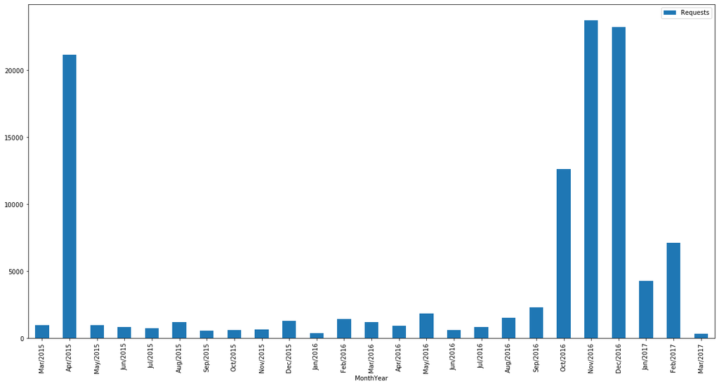

```python
df = pd.DataFrame([(k, v) for k, v in requests_per_month.items()], columns=['MonthYear', 'Requests'])

df.plot(x='MonthYear', y='Requests', kind='bar', figsize=(20,10))
```

#### Rework the dataframe so the months are sorted chronologically and plot again

- TIP: apply() is your friend!

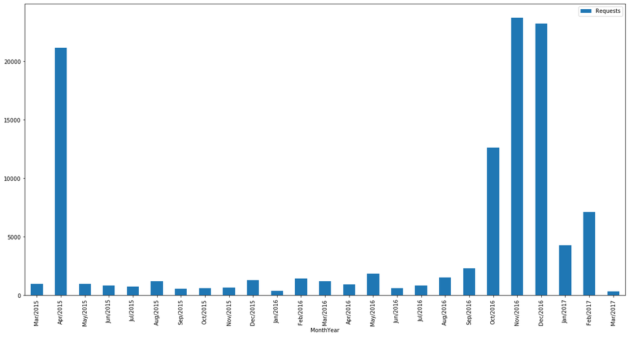

```python
# was already sorted!
df_sorted=df

df_sorted.plot(x='MonthYear', y='Requests', kind='bar', figsize=(20,10))
```

The huge peak at April/2015 is due to the fact that the LDF Server was used in a benchmarking study at a conference which was organised that same month. The peaks at the end of 2016, beginning 2017 are not fully clear currently but are definitely encouraging!

#### **2. Which clients made these requests?**

The client_user_agent_header contains a lot of details, take a prefix (length=12 for example) to cluster them together

#### **2a. How many different client types are there in the sample?**

```python
def extractClientPrefix(cuah):
    start = 0
    stop = 13
    return cuah[start:stop]

client_prefixes = (real_sample
                       .map(lambda logline: qualityCheck1(regex,logline))
                       .filter(lambda x: x[0]==1)
                       .map(lambda x: extractClientPrefix(x[1].client_user_agent_header))
                  )

diff_clients = client_prefixes.distinct()
print ("2a) " + str(diff_clients.count()))
```

```
2a) 49
```

#### 2b. Visualize the relative (%) number of requests per client for the dominant clients (>1000 requests & limit to maximum 20 clients)

```python
client_freqs = (real_sample
                    .map(lambda logline: qualityCheck1(regex,logline))
                    .filter(lambda x: x[0]==1)
                    .map(lambda x: (extractClientPrefix(x[1].client_user_agent_header), x))
                    .groupByKey()
               )

client_freqs_filtered = (client_freqs
                             .map(lambda x: (x[0], len(x[1])))
                             .filter(lambda x: x[1] > 1000)
                             .sortBy(lambda x: x[1], ascending=False)
                        )

most_frequent_clients = client_freqs_filtered.take(20)

print(most_frequent_clients)
```

```
[('Triple Patter', 37106), ('Java/1.8.0_77', 32359), ('Mozilla/5.0 (', 28056), ('2.7', 5846), ('AHC/1.0', 5315), ('Pingdom.com_b', 1171)]
```

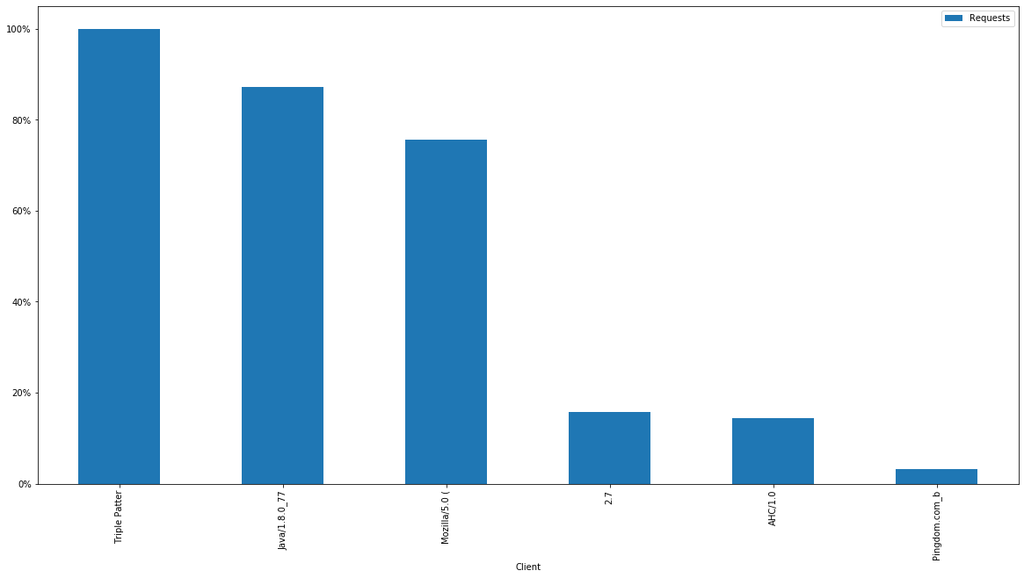

```python
import numpy as np
import matplotlib.ticker as mtick

df = pd.DataFrame([(k, v) for k, v in most_frequent_clients], columns=['Client', 'Requests'])
max_value = df['Requests'].max()
df[['Requests']] = df[['Requests']].divide(max_value).multiply(100)
ax = df.plot(x='Client', y='Requests', kind='bar', figsize=(20,10))
ax.yaxis.set_major_formatter(mtick.PercentFormatter())
```

#### **3. What is the preferred content type of the clients?**

#### **3a. How many different content types are requested?**

Note this is a tricky one, play around with a sample and you will notice that the logs are somewhat misformed, should be of the form: type;q=value, try and take care of the case when the ; was a , instead (bug in the server response)

```python
def qualityCheck2(cah):
    match = re.search("(\S+,q=\d)", cah)
    if (match == None):
        return (1, cah)
    return (0, cah)

accept_headers = (real_sample
                       .map(lambda logline: qualityCheck1(regex,logline))
                       .filter(lambda x: x[0]==1)
                       .map(lambda x: qualityCheck2(x[1].client_accept_header))
                  )

accept_headers_correct = (accept_headers
                              .filter(lambda x: x[0]==1)
                              .map(lambda x: x[1])
                         )
accept_headers_incorrect = (accept_headers
                                .filter(lambda x: x[0]==0)
                                .map(lambda x: x[1])
                           )

print (accept_headers_correct.take(5))
print (accept_headers_incorrect.take(5))

all_content_types = accept_headers_correct.union(accept_headers_incorrect)

print ("3a) " + str(all_content_types.distinct().count()))
all_content_types = (all_content_types
                         .flatMap(lambda x: [(w.split(';')[0].strip(),1) for w in x.split(',')])
                         .map(lambda x: (x[0].split('q=')[0], x[1]))
                    )
```

```
['*/*', '*/*', 'text/html,application/xhtml+xml,application/xml;q=0.9,*/*;q=0.8', '*/*', '*/*']
[]
3a) 52
```

#### **3b. Get the fractions of each content type? (Note: a request with 4 content types is equivalent to 4 requests as a simplification)**

```python
content_fractions = (all_content_types
                         .countByKey()
                    )
total_content_choices = (all_content_types
                             .map(lambda x: x[0])
                             .distinct()
                             .count()
                        )
```

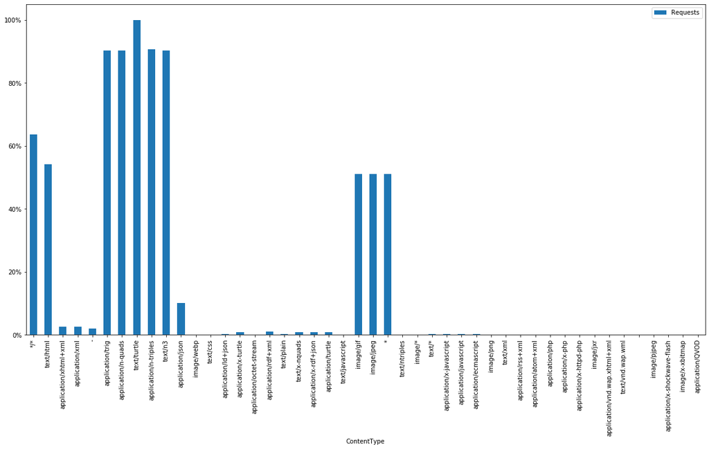

```python
df = pd.DataFrame([(k, v) for k, v in content_fractions.items()], columns=['ContentType', 'Requests'])
max_value = df['Requests'].max()
df[['Requests']] = df[['Requests']].divide(max_value).multiply(100)
ax = df.plot(x='ContentType', y='Requests', kind='bar', figsize=(20,10))
ax.yaxis.set_major_formatter(mtick.PercentFormatter())
```

#### **4. How effective has the cache been?**

#### **4a. What are the different values for cache status?**

```python
cache_values = (real_sample
                          .map(lambda logline: qualityCheck1(regex,logline))
                          .filter(lambda x: x[0]==1)
                          .map(lambda x: x[1].server_cache_status)
                     )

dist_values = cache_values.distinct().collect()
print (dist_values)
```

```
['-', 'EXPIRED', 'BYPASS', 'MISS', 'HIT']
```

#### **4b. What are their frequencies + one more pie chart?**

```python
total = cache_values.count()

cache_value_freqs = (real_sample
                          .map(lambda logline: qualityCheck1(regex,logline))
                          .filter(lambda x: x[0]==1)
                          .map(lambda x: (x[1].server_cache_status,1/total))
                          .reduceByKey(lambda x, y: x + y)
                          .collectAsMap()
                        )
print (cache_value_freqs)
```

```
{'-': 0.0003770028275212063, 'EXPIRED': 0.11620663345451258, 'BYPASS': 0.022961267447601057, 'MISS': 0.47622638122167005, 'HIT': 0.3842287150486972}
```

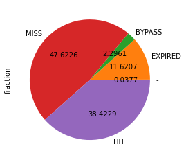

```python
df = pd.DataFrame([(k, v) for k, v in cache_value_freqs.items()], columns=['CacheValue', 'fraction'])
df = df.set_index('CacheValue')
df.plot(kind='pie', x = 'CacheValue', y = 'fraction',autopct='%.4f',legend=False)
```

#### **5. What kind of triple patterns were requested? (uri_request)**

- a triple patterns consists of a subject, predicate and an object (s,p,o)
- some of these can be left blank, (*,p,o) matches any subject with a give p and o for example
- Make a bar plot (logscale) show the number of times a request has (s,p,o), (*,p,o), ... (*,*,*)

```python
# extract spo string
requests = (real_sample
                  .map(lambda logline: qualityCheck1(regex,logline))
                  .filter(lambda x: x[0]==1)
                  .map(lambda x: x[1].uri_request)
            )

# convert spo string to a template such as: ***, s**, *p*, **o, sp*, ..., spo.
def convertToTripleTemplate(req):
    pattern = ""

    if "subject=" in req:
        pattern += "s"
    else:
        pattern += "*"

    if "predicate=" in req:
        pattern += "p"
    else:
        pattern += "*"

    if "object=" in req:
        pattern += "o"
    else:
        pattern += "*"

    return pattern

test = "GET /2014/en?object=%2217842723%22%5E%5Ehttp%3A%2F%2Fwww.w3.org%2F2001%2FXMLSchema%23integer HTTP/1.1"
print(convertToTripleTemplate(test))

# calculate patterns
triplepatterns = requests.map(convertToTripleTemplate)

# collect
patternFreqs = (triplepatterns
                    .map(lambda r: (r, 1))
                    .reduceByKey(lambda x, y: x+y)
                    .collectAsMap()
               )

print(patternFreqs)
```

```
**o
{'s**': 10032, 'spo': 44618, 'sp*': 35315, '***': 2549, '*po': 5656, '*p*': 5116, '**o': 7929, 's*o': 190}
```

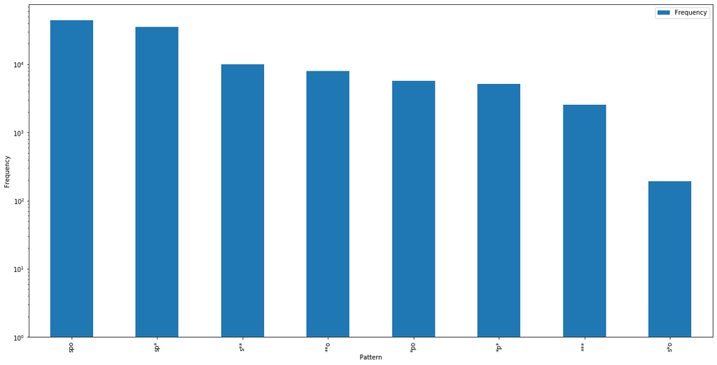

```python
df = pd.DataFrame(index=patternFreqs.keys(), data={"Frequency" : list(patternFreqs.values())}).sort_values("Frequency", ascending=False)
# logscale on y-axis!
pl = df.plot(kind='bar', figsize=(20,10), log=True)
pl.set_ylabel("Frequency")
pl.set_xlabel("Pattern")
```

#### **6. Is there a trend in the LDF server usage? (number of requests per day)**

#### **6a. Start by mapping every date on an integer number (be pragmatic, it shouldn't be perfect!), to allow plotting the values on the X-axis**

(TIP: Do you remember the purpose of broadcast variables and accumulators?)

```python
mapping = {'Jan':3, 'Feb':4, 'Mar':5, 'Apr':6, 'May':7, 'Jun':8, 'Jul':9, 'Aug':10, 'Sep':11,
           'Oct':0, 'Nov':1, 'Dec':2} # Why out of order?

def extractDayMonthYear(slt):
    # keep in mind that the mapping dictionary should be shipped to the workers
    slt_split = slt.split("/")
    day = int(slt_split[0].strip('['))
    month = mapping.get(slt_split[1])
    year  = int(slt_split[2].split(":")[0])
    return (day,month,year)

test = "[05/Mar/2015:21:35:07 +0000]"
print(extractDayMonthYear(test))
```

```
(5, 5, 2015)
```

```python
mapped_dates = (real_sample
                    .map(lambda logline: qualityCheck1(regex,logline))
                    .filter(lambda x: x[0]==1)
                    .map(lambda x: extractDayMonthYear(x[1].server_local_time))
                    .map(lambda dmy: (dmy[0]+dmy[1]*100+dmy[2]*10000,1))
           )

day_month_frequencies = (mapped_dates
                              .reduceByKey(lambda x,y: x + y)
                              .sortByKey()
                   )
#print(day_month_frequencies.collect())
```

#### **6b. Create a (nice!) bar chart with the number of request per day**

```
734
```

```
[Text(0, 0, '20150001'),
```

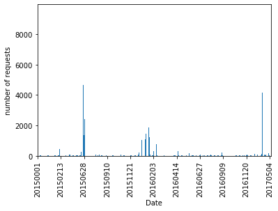

```python
frequencies = (day_month_frequencies
                      .collectAsMap()
                   )

fig, ax = plt.subplots(1,1)
df = pd.DataFrame([(k, v) for k, v in frequencies.items()], columns=['Date', 'count'])
df.plot(kind='bar',ax=ax, x='Date',y='count', legend=False)

print(len(df.Date))

# clean it up a little
ax.set_ylabel("number of requests")
ax.set_xticks(list(range(0,len(df.Date),len(df.Date)//10)))
ax.set_xticklabels([df.Date.tolist()[i] for i in range(0,len(df.Date),len(df.Date)//10)])
```

#### **7. Estimate the availability of the LDF server based on the number of pingdom requests**

Pingdom was used to test the high availability of the server by sending a request every minute

#### 7a. What's the number of Pingdom requests in the sample

```python
num_pingdom_requests = (real_sample
                    .map(lambda logline: qualityCheck1(regex,logline))
                    .filter(lambda x: x[0]==1)
                    .filter(lambda x: "pingdom" in x[1].client_user_agent_header)
                    .count()
                )

print(num_pingdom_requests)
```

```
1171
```

#### 7b. Calculate the maximum number of pingdom requests possible

```python
pingdom_requests_time = (real_sample
                    .map(lambda logline: qualityCheck1(regex,logline))
                    .filter(lambda x: x[0]==1)
                    .filter(lambda x: "pingdom" in x[1].client_user_agent_header)
                    .map(lambda x: x[1].server_local_time)
                )

#print(pingdom_requests_time.collect())
first_time = pingdom_requests_time.first()
last_time = pingdom_requests_time.collect()[-1]

print(first_time)
print(last_time)
```

```
06/Mar/2015:12:58:07 +0000
06/Mar/2017:20:53:04 +0000
```

#### TIP: you can use the datetime package to work to perform calculations on time

```python
import datetime

first_timestamp = datetime.datetime.strptime(first_time, "%d/%b/%Y:%H:%M:%S %z")
last_timestamp = datetime.datetime.strptime(last_time, "%d/%b/%Y:%H:%M:%S %z")

max_number_of_pings = ((last_timestamp-first_timestamp).total_seconds()) // 60 # sending a request every minute

print(max_number_of_pings)
```

```
1053114.0
```

#### 7c. What is the expected number of pingdom requests in the sample, use this to estimate the availability of the LDF server.

```python
expected = max_number_of_pings * fraction
availability = (num_pingdom_requests/expected)*100

print(expected)
print('Estimated availibility is: ' + str(availability) + " %")
```

```
2106.228
Estimated availibility is: 55.597019885786345 %
```

#### 8. What are the top 5 days w.r.t. to the number of unique daily users? What is the average number of unique daily users?

#### 8a. calculate the number of distinct ip's per day in a scalable way!

```python
# top 5 days w.r.t. the number of unique daily users
unique_daily_users = (real_sample
                        .map(lambda logline: qualityCheck1(regex,logline))
                        .filter(lambda x: x[0]==1)
                        .map(lambda x: (extractDayMonthYear(x[1].server_local_time),x[1].client_ip) )
                        .distinct()
                        .map(lambda x: (x[0],1) )
                        .reduceByKey(lambda x, y: x + y)
                     )

top_days = (unique_daily_users
                .map(lambda x:(x[1],x[0]))
                .sortByKey(False) # descending order
           ).take(5)

print (top_days)
```

```
[(61, (19, 1, 2016)), (60, (18, 1, 2016)), (55, (21, 1, 2016)), (45, (16, 1, 2016)), (36, (29, 6, 2015))]
```

```python
# average number of unique daily users
total_days = unique_daily_users.count()
av_daily_users = (unique_daily_users
                     .map(lambda x : x[1])
                     .reduce(lambda x,y:y+x)
                 )/total_days

print(av_daily_users)
```

```
9.245231607629428
```